# Analyse der Matoma-HaNS-Daten

Author

Sebastian Sauer

Published

May 23, 2025

# 1 Setup

## 1.1 R-Pakete starten

```r
library(targets)
library(tidyverse)
library(ggokabeito)
library(easystats)
library(gt)
library(ggfittext)
library(scales)
library(visdat)
library(collapse)
library(ggpubr)
```

```r
theme_set(theme_minimal())
```

## 1.2 Optionen setzen

```r
options(lubridate.week.start = 1)  # Monday as first day
#options(collapse_mask = "all") # use collapse for all dplyr operations
options(chromote.headless = "new")  # Chrome headleass needed for gtsave
```

## 1.3 Roh-Daten laden und inspizieren (data_all_fact)

```r
tar_load(data_all_fct)
```

### 1.3.1 Dimension

Der Roh-Datensatz verfügt über

- 19086 Zeilen
- 8399 Spalten (Dubletten und Spalten mit Bildern bereits entfernt)

Jede Zeile entspricht einem “Visit”.

### 1.3.2 Erster Blick

```r
data_all_fct_head100 <-
data_all_fct %>%
  select(1:100) %>%
  slice_head(n = 100)
```

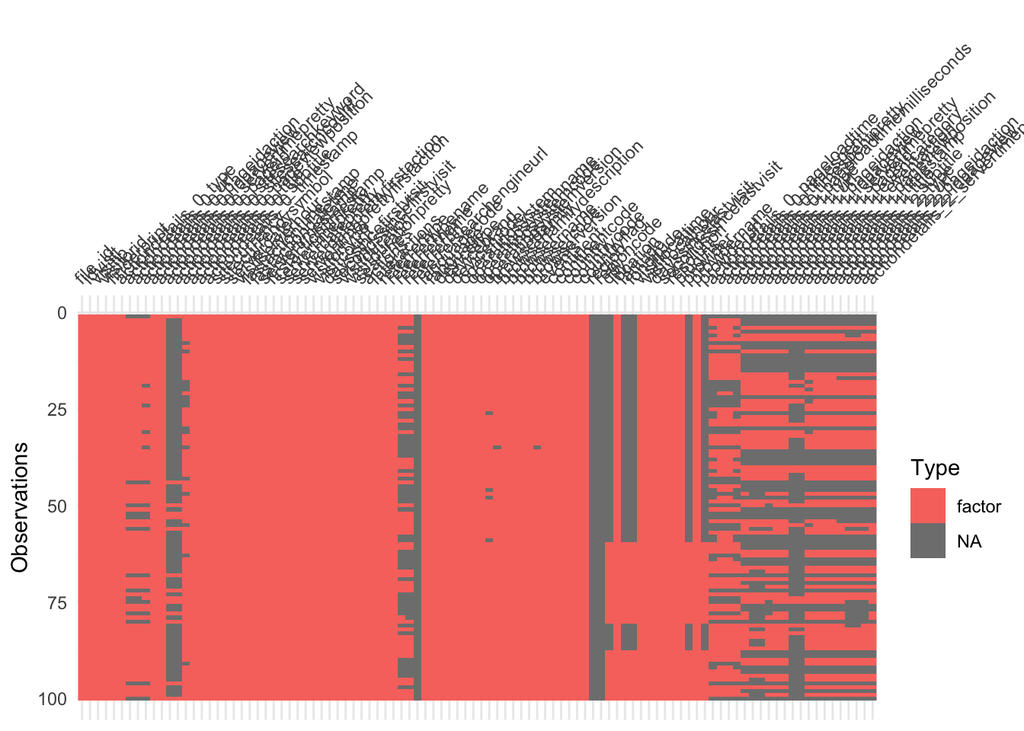

```r
data_all_fct_head100 %>%
  visdat::vis_dat()
```

### 1.3.3 Namen (1-100)

```r
data_all_fct_head100 %>%
  names()
```

```
  [1] "file_id"
  [2] "idvisit"
  [3] "visitip"
  [4] "visitorid"
  [5] "fingerprint"
  [6] "actiondetails_0_type"
  [7] "actiondetails_0_url"
  [8] "actiondetails_0_pageidaction"
  [9] "actiondetails_0_idpageview"
 [10] "actiondetails_0_servertimepretty"
 [11] "actiondetails_0_pageid"
 [12] "actiondetails_0_sitesearchkeyword"
 [13] "actiondetails_0_sitesearchcount"
 [14] "actiondetails_0_pageviewposition"
 [15] "actiondetails_0_title"
```

[output cut: 85 more lines]

### 1.3.4 Werte der erst 100 Spalten

```r
data_all_fct_head100 %>%
  glimpse()
```

```
Rows: 100
Columns: 100
$ file_id                                  <fct> matomo_export_2023-03-23.csv,…
$ idvisit                                  <fct> 17, 16, 15, 13, 14, 11, 10, 1…
$ visitip                                  <fct> 87.150.0.0, 217.84.0.0, 90.18…
$ visitorid                                <fct> 9b735f0eb17af6a8, c77ae8b840d…
$ fingerprint                              <fct> 86408e41c606f8f7, 0584640e01c…
$ actiondetails_0_type                     <fct> search, action, action, actio…
$ actiondetails_0_url                      <fct> NA, https://hans.th-nuernberg…
$ actiondetails_0_pageidaction             <fct> NA, 2, 2, 3, 2, 9, 3, 4, 2, 4…
$ actiondetails_0_idpageview               <fct> NA, PlZbGn, 0f7b07, A6owU2, h…
$ actiondetails_0_servertimepretty         <fct> "Mar 23, 2023 21:18:53", "Mar…
$ actiondetails_0_pageid                   <fct> 325, 324, 323, 164, 176, 145,…
$ actiondetails_0_sitesearchkeyword        <fct> "GDI", NA, NA, NA, NA, NA, NA…
$ actiondetails_0_sitesearchcount          <fct> 0, NA, NA, NA, NA, NA, NA, NA…
```

[output cut: 87 more lines]

### 1.3.5 Datensatz data_slim_filtered, Zeilen 1-100

```r
tar_load(data_slim_filtered)

data_slim_filtered %>%
  slice(1:100) |>
  gt()
```

| nr | type | value | idvisit |
| --- | --- | --- | --- |
| 0 | subtitle | https://hans.th-nuernberg.de/login | 1 |
| 0 | subtitle | https://hans.th-nuernberg.de/login?evalId=none&user=undefined&role=undefined | 1 |
| 0 | subtitle | https://hans.th-nuernberg.de/ | 1 |
| 0 | subtitle | https://hans.th-nuernberg.de/login?evalId=none&role=undefined | 1 |
| 0 | timestamp | 2023-03-23 14:20:12 | 1 |
| 0 | timestamp | 2024-06-06 11:19:16 | 1 |
| 0 | timestamp | 2022-12-05 15:33:45 | 1 |
| 0 | timestamp | 2023-10-04 16:19:46 | 1 |
| 1 | eventcategory | click_videocard | 1 |
| 1 | eventcategory | login | 1 |
| 1 | eventaction | Einführung in HAnS | 1 |
| 1 | eventaction | success | 1 |
| 1 | timestamp | 2023-03-23 14:20:26 | 1 |
| 1 | timestamp | 2024-06-06 11:21:07 | 1 |
| 1 | timestamp | 2022-12-05 15:33:49 | 1 |
| 1 | timestamp | 2023-10-04 16:19:54 | 1 |
| 1 | subtitle | https://hans.th-nuernberg.de/ | 1 |
| 1 | subtitle | https://hans.th-nuernberg.de/login?evalId=none&user=undefined&role=undefined | 1 |
| 1 | subtitle | Category: ""click_videocard', Action: ""Einführung in HAnS"" | 1 |
| 1 | subtitle | Category: ""login', Action: ""success"" | 1 |
| 2 | subtitle | Category: ""click_toggle', Action: ""Evaluation"" | 1 |
| 2 | subtitle | https://hans.th-nuernberg.de/video-player?uuid=b57c1dfe-a667-48a6-b43d-dac7e600ae8c | 1 |
| 2 | subtitle | https://hans.th-nuernberg.de/?evalId=none&role=developer | 1 |
| 2 | timestamp | 2023-03-23 14:20:28 | 1 |
| 2 | timestamp | 2022-12-05 15:33:49 | 1 |
| 2 | timestamp | 2023-10-04 16:19:54 | 1 |
| 2 | eventcategory | click_toggle | 1 |
| 2 | eventaction | Evaluation | 1 |
| 3 | eventcategory | click_button | 1 |
| 3 | eventcategory | videoplayer_click | 1 |

[output cut: 70 more lines]

# 2 Datensatz nur User

Entfernt man Developer, Admins und Lecturers aus dem Roh-Datensatz so bleiben weniger Zeilen übrig:

```r
tar_load(data_users_only)
```

- 11383 Zeilen
- 8399 Spalten

# 3 Datensatz mit Anzahl der Aktionen pro User

```r
tar_load(count_action)
```

# 4 Zeitraum

## 4.1 Beginn/Ende der Daten

```r
tar_load(config)
```

```r
tar_load(time_minmax)
```

```r
time_minmax |>
  summarise(time_min = min(time_min, na.rm = T),
            time_max = max(time_max, na.rm = T)) |>
  gt()
```

| time_min | time_max |
| --- | --- |
| 2022-12-05 15:33:45 | 2025-03-03 14:08:54 |

Diese Statistik wurde auf Basis des Datenobjekts `data_slim_filtered` berechnet.

## 4.2 Days since last visit

```r
tar_load(time_visit_wday)
tar_load(time_since_last_visit)
```

```r
time_since_last_visit <-
time_since_last_visit |>
  mutate(dayssincelastvisit = as.numeric(dayssincelastvisit))

time_since_last_visit |>
  datawizard::describe_distribution(dayssincelastvisit) |>
  knitr::kable(digits = 2)
```

| Variable | Mean | SD | IQR | Min | Max | Skewness | Kurtosis | n | n_Missing |
| --- | --- | --- | --- | --- | --- | --- | --- | --- | --- |
| dayssincelastvisit | 6.3 | 15.38 | 0 | 1 | 92 | 3.32 | 10.84 | 18924 | 162 |

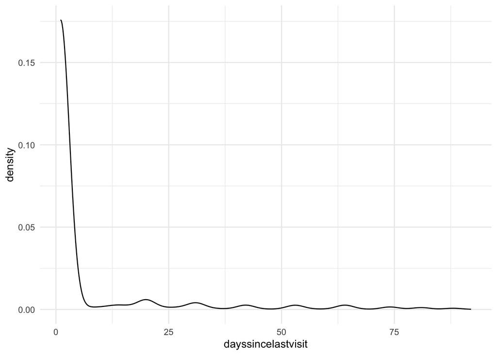

```r
time_since_last_visit |>
  ggplot(aes(x=dayssincelastvisit)) +
  geom_density()
```

## 4.3 Visits im Zeitverlauf

Wie viele Visits (von Hans) gab es?

### 4.3.1 Pro Monat

```r
time_visit_wday_summary <-
time_visit_wday |>
  ungroup() |>
  mutate(month_start = floor_date(date_time, "month")) |>
  mutate(month_name = month(date_time, label = TRUE, abbr = FALSE),
         month_num = month(date_time, label = FALSE),
         year_num = year(date_time)) |>
  group_by(year_num, month_num) |>
  summarise(n = n())
```

```r
time_visit_wday_summary |>
  gt()
```

| month_num | n |
| --- | --- |
| 2022 |  |
| 12 | 25 |
| 2023 |  |
| 1 | 20 |
| 2 | 77 |
| 3 | 99 |
| 4 | 219 |
| 5 | 300 |
| 6 | 246 |
| 7 | 390 |
| 8 | 20 |
| 9 | 27 |
| 10 | 22 |
| 11 | 8 |
| 12 | 98 |
| 2024 |  |
| 1 | 552 |
| 2 | 71 |
| 3 | 51 |
| 4 | 94 |
| 5 | 303 |
| 6 | 200 |
| 7 | 192 |
| 8 | 6 |
| 9 | 5 |
| 10 | 8 |
| 11 | 149 |
| 12 | 650 |
| 2025 |  |
| 1 | 830 |
| 2 | 131 |
| 3 | 2 |

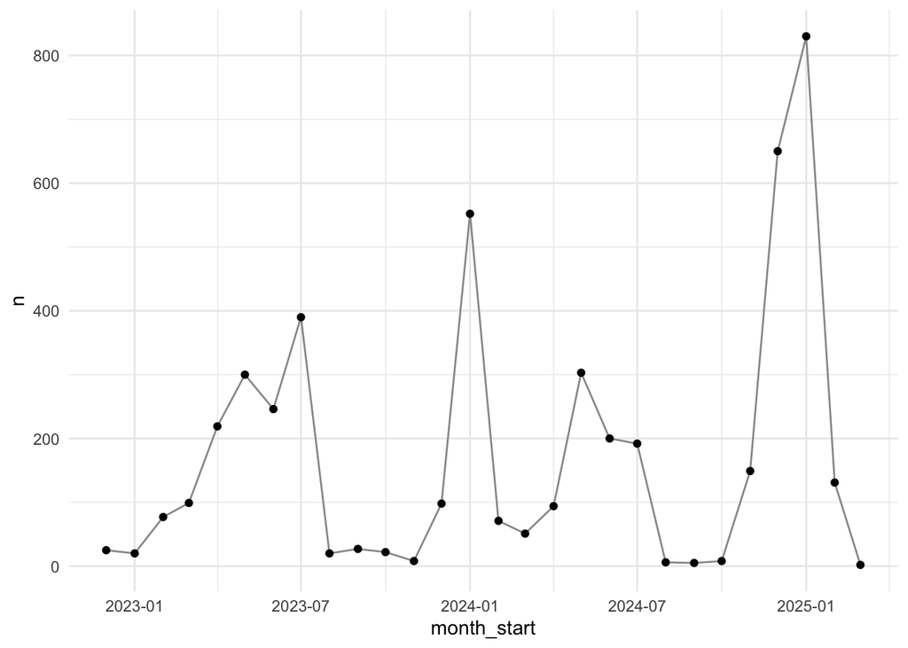

```r
time_visit_wday_summary2 <-
time_visit_wday |>
  ungroup() |>
  mutate(month_start = floor_date(date_time, "month")) |>
  mutate(month_name = month(date_time, label = TRUE, abbr = FALSE),
         month_num = month(date_time, label = FALSE),
         year_num = year(date_time)) |>
  group_by(year_num, month_start) |>
  summarise(n = n())


time_visit_wday_summary2 |>
  ggplot(aes(x = month_start, y = n)) +
  geom_line(group = 1, color = "grey60") +
  geom_point()
```

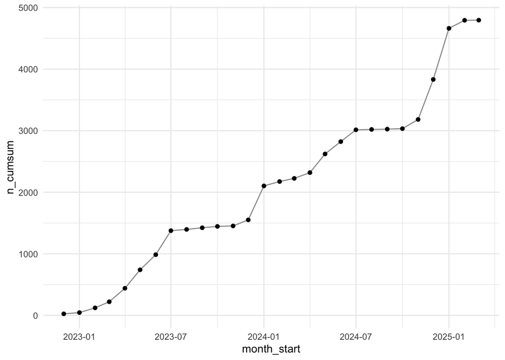

```r
time_visit_wday_summary2 <-
time_visit_wday |>
  ungroup() |>
  mutate(month_start = floor_date(date_time, "month")) |>
  mutate(month_name = month(date_time, label = TRUE, abbr = FALSE),
         month_num = month(date_time, label = FALSE),
         year_num = year(date_time)) |>
  group_by(year_num, month_start) |>
  summarise(n = n()) |>
  ungroup() |>
  mutate(n_cumsum = cumsum(n))


time_visit_wday_summary2 |>
  ggplot(aes(x = month_start, y = n_cumsum)) +
  geom_line(group = 1, color = "grey60") +
  geom_point()
```

## 4.4 Statistiken

Die folgenden Statistiken beruhen auf dem Datensatz `data_slim_filtered`:

```r
glimpse(data_slim_filtered)
```

```
Rows: 3,597,119
Columns: 4
$ nr      <int> 0, 0, 0, 0, 0, 0, 0, 0, 1, 1, 1, 1, 1, 1, 1, 1, 1, 1, 1, 1, 2,…
$ type    <fct> subtitle, subtitle, subtitle, subtitle, timestamp, timestamp, …
$ value   <chr> "https://hans.th-nuernberg.de/login", "https://hans.th-nuernbe…
$ idvisit <int> 1, 1, 1, 1, 1, 1, 1, 1, 1, 1, 1, 1, 1, 1, 1, 1, 1, 1, 1, 1, 1,…
```

`nr` fasst die Nummer der Aktion innerhalb eines bestimmten Visits.

## 4.5 Mit allen Daten (den 499er-Daten)

```r
tbl_count_action <-
count_action |>
  describe_distribution(nr_max) |>
  gt() |>
  fmt_number(columns = where(is.numeric),
             decimals = 2)

tbl_count_action
```

| Variable | Mean | SD | IQR | Min | Max | Skewness | Kurtosis | n | n_Missing |
| --- | --- | --- | --- | --- | --- | --- | --- | --- | --- |
| nr_max | 129.35 | 152.20 | 161.00 | 1.00 | 499.00 | 1.40 | 0.77 | 4,795.00 | 0.00 |

```r
gtsave(tbl_count_action, filename = "reports/tbl_count_action.png")
```

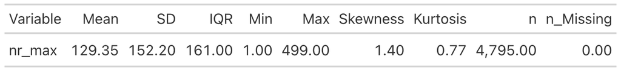

`nr_max` gibt den Maximalwert von `nr` zurück, sagt also, wie viele Aktionen maximal von einem Visitor ausgeführt wurden.

Betrachtet man die Anzahl der Aktionen pro Visitor näher, so fällt auf, dass der Maximalwert (499) sehr häufig vorkommt:

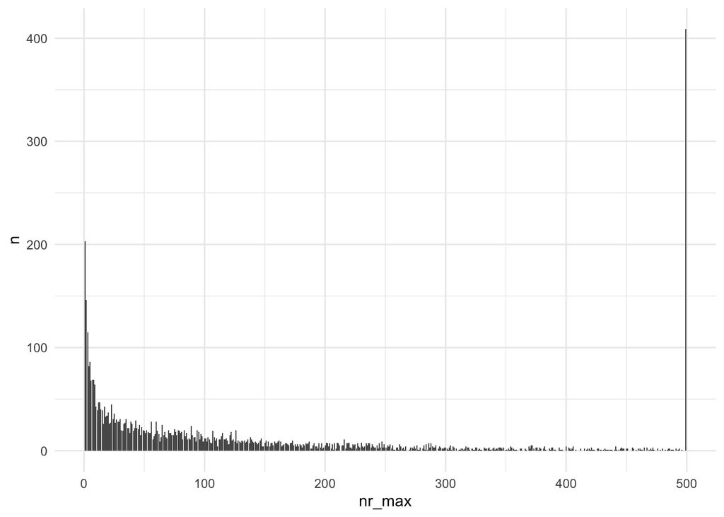

```r
count_action |>
  count(nr_max) |>
  ggplot(aes(x = nr_max, y = n)) +
  geom_col()
```

Hier noch in einer anderen Darstellung:

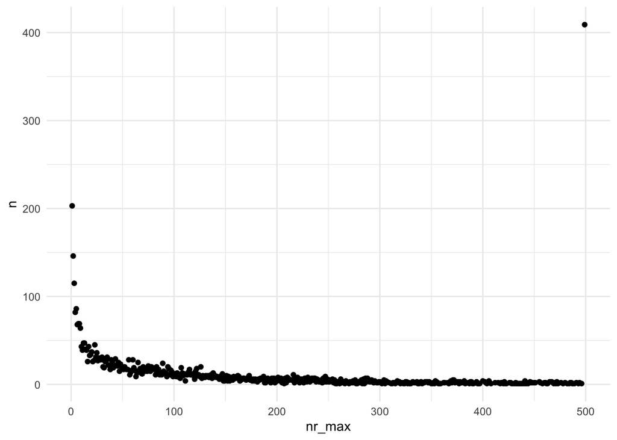

```r
count_action |>
  count(nr_max) |>
  ggplot(aes(x = nr_max, y = n)) +
  geom_point()
```

Der Maximalwert ist einfach auffällig häufig:

```r
count_action |>
  count(nr_max == 499) |>
  gt()
```

| nr_max == 499 | n |
| --- | --- |
| FALSE | 4386 |
| TRUE | 409 |

Es erscheint plausibel, dass der Maximalwert alle “gekappten” (*zensierten*, abgeschnittenen) Werte fasst, also viele Werte, die eigentlich größer wären (aber dann zensiert wurden).

## 4.6 Nur Visitors, für die weniger als 500 Aktionen protokolliert sind

```r
count_action2 <-
count_action |>
  filter(nr_max != 499)

count_action2 |>
  describe_distribution(nr_max) |>
  gt() |>
  fmt_number(columns = where(is.numeric),
             decimals = 2)
```

| Variable | Mean | SD | IQR | Min | Max | Skewness | Kurtosis | n | n_Missing |
| --- | --- | --- | --- | --- | --- | --- | --- | --- | --- |
| nr_max | 94.89 | 106.74 | 122.00 | 1.00 | 496.00 | 1.56 | 2.01 | 4,386.00 | 0.00 |

## 4.7 Verteilung

## 4.8 Mit den 499er-Daten

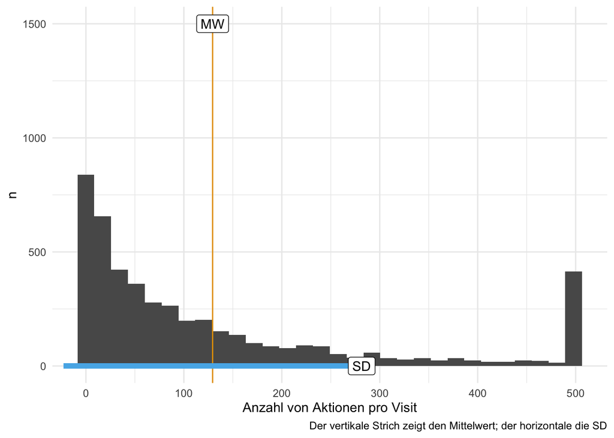

```r
count_action_avg = mean(count_action$nr_max)
count_action_sd = sd(count_action$nr_max)

count_action |>
  ggplot() +
  geom_histogram(aes(x = nr_max)) +
  labs(x = "Anzahl von Aktionen pro Visit",
       y = "n",
       caption = "Der vertikale Strich zeigt den Mittelwert; der horizontale die SD") +
  theme_minimal() +
  geom_vline(xintercept = count_action_avg,
             color = palette_okabe_ito()[1]) +
  geom_segment(x = count_action_avg-count_action_sd,
               y = 0,
               xend = count_action_avg + count_action_sd,
               yend = 0,
               color = palette_okabe_ito()[2],
               size = 2) +
  annotate("label", x = count_action_avg, y = 1500, label = "MW") +
  annotate("label", x = count_action_avg + count_action_sd, y = 0, label = "SD")
```

```r
  #geom_label(aes(x = count_action_avg), y = 1, label = "Mean")
```

- Mittelwert der Aktionen pro Visit: 129.35.
- SD der Aktionen pro Visit: 152.2.

## 4.9 Ohne 499er-Daten

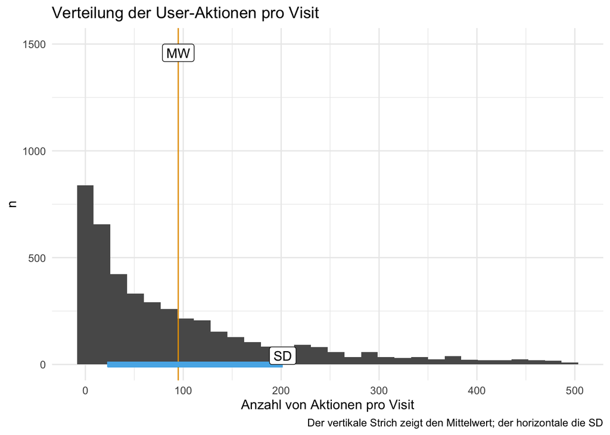

```r
count_action_avg2 = mean(count_action2$nr_max)
count_action_sd2 = sd(count_action2$nr_max)

count_action2 |>
  ggplot() +
  geom_histogram(aes(x = nr_max)) +
  labs(x = "Anzahl von Aktionen pro Visit",
       y = "n",
       title = "Verteilung der User-Aktionen pro Visit",
       caption = "Der vertikale Strich zeigt den Mittelwert; der horizontale die SD") +
  theme_minimal() +
  geom_vline(xintercept = count_action_avg2,
             color = palette_okabe_ito()[1]) +
  geom_segment(x = count_action_avg-count_action_sd2,
               y = 0,
               xend = count_action_avg2 + count_action_sd2,
               yend = 0,
               color = palette_okabe_ito()[2],
               size = 2) +
  annotate("label", x = count_action_avg2, y = 1500, label = "MW", vjust = "top") +
  annotate("label", x = count_action_avg2 + count_action_sd2, y = 0, label = "SD", vjust = "bottom")
```

```r
  #geom_label(aes(x = count_action_avg), y = 1, label = "Mean")
```

- Mittelwert der Aktionen pro Visit: 94.89.
- SD der Aktionen pro Visit: 106.74.

# 5 Verweildauer pro Visit

Die Visit-Zeit wurde auf 600 Min. trunkiert/begrenzt.

```r
tar_load(time_spent)
tar_load(time_duration)

time_spent <-
  time_spent |>
  mutate(t_min = as.numeric(time_diff, units = "mins")) |>
  filter(t_min < 600)
```

```r
time_spent |>
  summarise(
    mean_time_diff = round(mean(time_diff), 2),
    sd_time_diff = sd(time_diff),
    min_time_diff = min(time_diff),
    max_time_diff = max(time_diff)
  ) |>
  summarise(
    mean_time_diff_avg = mean(mean_time_diff),
    sd_time_diff_avg = mean(sd_time_diff, na.rm = TRUE),
    min_time_diff_avg = mean(min_time_diff),
    max_time_diff_avg = mean(max_time_diff)
  ) |>
  gt() |>
  fmt_number(columns = everything(),
             decimals = 2)
```

| mean_time_diff_avg | sd_time_diff_avg | min_time_diff_avg | max_time_diff_avg |
| --- | --- | --- | --- |
| 142.52 | 0.00 | 142.52 | 142.52 |

```r
tar_load(time_duration)

time_duration |>
  summarise(duration_sec_avg = mean(visitduration_sec, na.rm = TRUE))  |>
  mutate(duration_min_avg = duration_sec_avg / 60)
```

```
  duration_sec_avg duration_min_avg
1         1289.434         21.49056
```

## 5.2 Verweildauer-Statistiken in Minuten

```r
time_spent_summary <-
time_spent |>
  summarise(
    mean_t_min = mean(t_min),
    sd_t_min = sd(t_min),
    min_t_min = min(t_min),
    max_t_min = max(t_min)
  ) |>
   summarise(
    mean_t_min_avg = mean(mean_t_min),
    sd_t_min_avg = mean(sd_t_min, na.rm = TRUE),
    min_t_min_avg = mean(min_t_min),
    max_t_min_avg = mean(max_t_min)
  )

time_spent_summary |>
  gt() |>
  fmt_number(columns = everything(),
             decimals = 2)
```

| mean_t_min_avg | sd_t_min_avg | min_t_min_avg | max_t_min_avg |
| --- | --- | --- | --- |
| 142.52 | 0.00 | 142.52 | 142.52 |

```r
small_padding_theme <- ggpubr::ttheme(
  tbody.style = tbody_style(size = 8), # Smaller font size can help
  colnames.style = colnames_style(size = 9, face = "bold"),
  padding = unit(c(2, 2), "mm") # Reduce horizontal and vertical padding
)
```

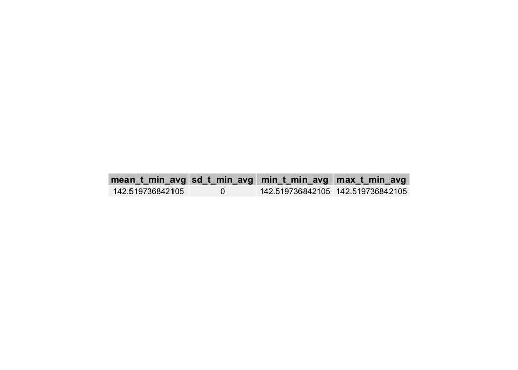

```r
ggpubr::ggtexttable(time_spent_summary,
                    rows = NULL,
                    theme = small_padding_theme)
```

## 5.3 Visualisierung der Verweildauer

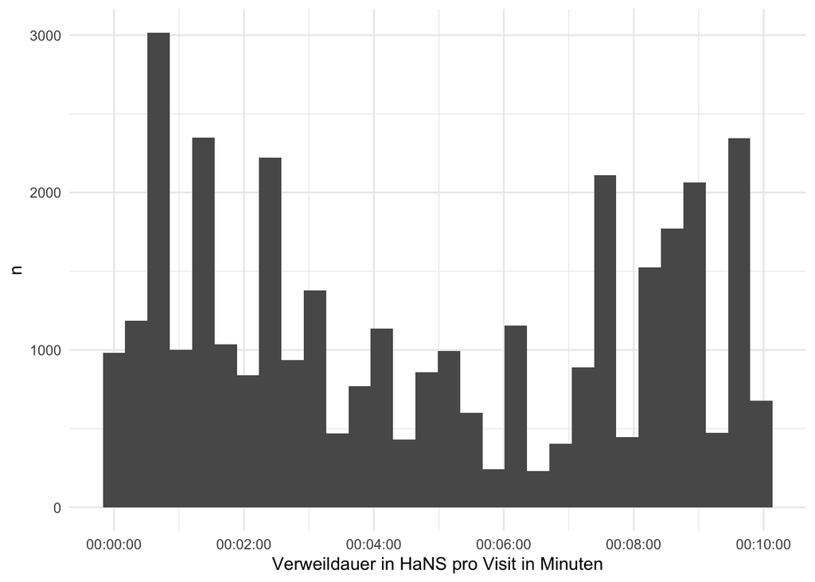

```r
time_spent |>
  ggplot(aes(x = t_min)) +
  geom_histogram() +
  scale_x_time() +
  theme_minimal() +
  labs(y = "n",
       x = "Verweildauer in HaNS pro Visit in Minuten")
```

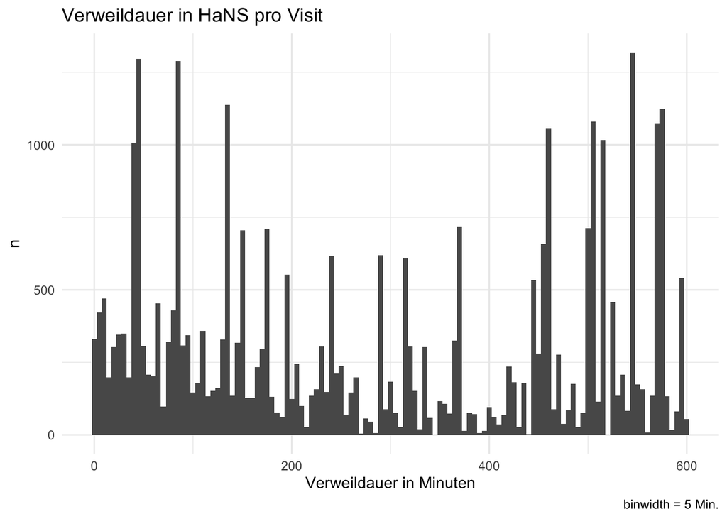

```r
time_spent |>
  ggplot(aes(x = t_min)) +
  geom_histogram(binwidth = 5) +
  theme_minimal() +
  labs(y = "n",
       x = "Verweildauer in Minuten",
       title = "Verweildauer in HaNS pro Visit",
       caption = "binwidth = 5 Min.")
```

### 5.3.3 Zeitdauer begrenzt auf 1-120 Min.

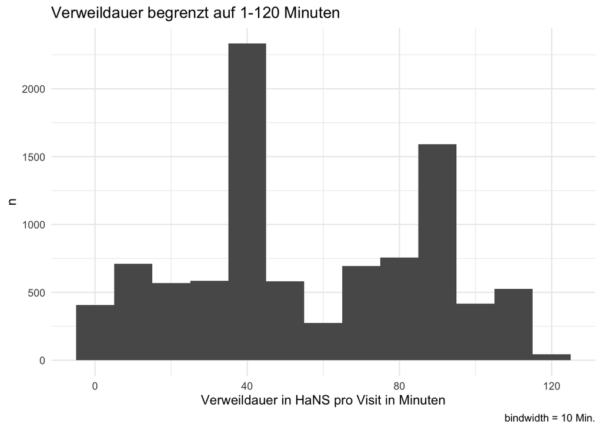

```r
time_spent2 <-
time_spent |>
  filter(t_min > 1, t_min < 120)

time_spent2 |>
  ggplot(aes(x = t_min)) +
  geom_histogram(binwidth = 10) +
  theme_minimal() +
  labs(y = "n",
       x = "Verweildauer in HaNS pro Visit in Minuten",
       title = "Verweildauer begrenzt auf 1-120 Minuten",
       caption = "bindwidth = 10 Min.")
```

### 5.3.4 Veränderung der Verweildauer im Zeitverlauf

```r
time_spent_by_month <-
  time_spent |>
  mutate(date = ymd_hms(value)) |>
  mutate(month_start = floor_date(date, "month")) |>
  mutate(month_name = month(month_start, label = TRUE, abbr = FALSE),
         month_num = month(month_start, label = FALSE),
         year = year(month_start)) |>
  group_by(month_num, year) |>
  summarise(time_spent_month_avg = mean(t_min, na.rm = TRUE),
            time_spent_month_sd = sd(t_min, na.rm = TRUE)) |>
  arrange(year, month_num)

time_spent_by_month |>
  gt() |>
  fmt_auto()
```

| year | time_spent_month_avg | time_spent_month_sd |
| --- | --- | --- |
| 12 |  |  |
| 2,022 | 10 | 0 |
| 2,023 | 268.264 | 196.857 |
| 2,024 | 251.396 | 176.941 |
| 2 |  |  |
| 2,023 | 421 | 180.428 |
| 2,024 | 309.517 | 202.612 |
| 2,025 | 214.55 | 172.93 |
| 3 |  |  |
| 2,023 | 107.075 | 86.062 |
| 2,025 | 9 | 0 |
| 4 |  |  |
| 2,023 | 379.868 | 230.16 |
| 2,024 | 112 | 0 |
| 7 |  |  |
| 2,023 | 187.708 | 160.938 |
| 2,024 | 566.692 | 50.806 |
| 8 |  |  |
| 2,023 | 129.368 | 105.653 |
| 2,024 | 582 | 0 |
| 9 |  |  |
| 2,023 | 414.391 | 208.662 |
| 10 |  |  |
| 2,023 | 181.716 | 115.475 |
| 2,024 | 43.284 | 12.632 |
| 1 |  |  |
| 2,024 | 170.763 | 141.968 |
| 2,025 | 336.1 | 199.91 |
| 5 |  |  |
| 2,024 | 268.909 | 130.843 |
| 6 |  |  |
| 2,024 | 336.303 | 182.84 |
| 11 |  |  |
| 2,024 | 374.266 | 209.407 |

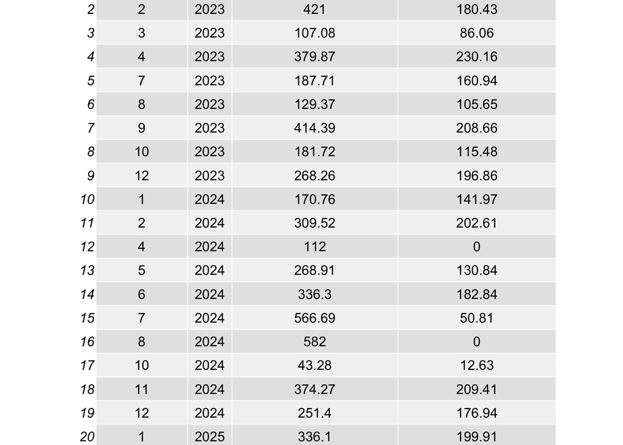

```r
time_spent_by_month |>
  mutate(time_spent_month_avg = round(time_spent_month_avg, 2),
         time_spent_month_sd = round(time_spent_month_sd, 2)) |>
  ggtexttable()
```

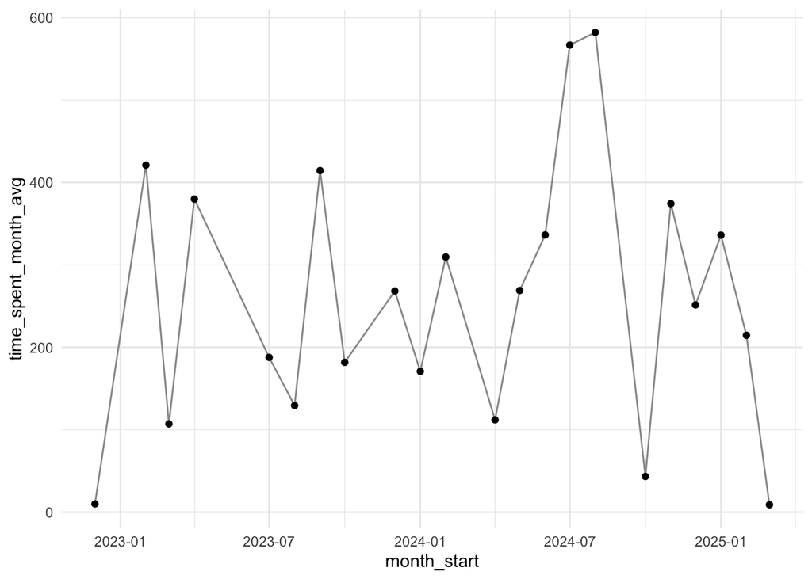

```r
time_spent_by_month_name <-
time_spent |>
  mutate(date = ymd_hms(value)) |>
  mutate(month_start = floor_date(date, "month")) |>
  mutate(month_name = month(month_start, label = TRUE, abbr = FALSE),
         month_num = month(month_start, label = FALSE),
         year = year(month_start)) |>
  group_by(month_start, year) |>
  summarise(time_spent_month_avg = mean(t_min, na.rm = TRUE),
            time_spent_month_sd = sd(t_min, na.rm = TRUE))

time_spent_by_month_name |>
ggplot(aes(x = month_start, y = time_spent_month_avg)) +
  geom_line(group = 1, color = "grey60") +
    geom_point()
```

# 6 Was machen die User?

```r
tar_load(count_action_type)
```

## 6.1 Häufigkeiten

### 6.1.1 Nach Kategorien

```r
count_action_type_counted <-
count_action_type |>
  drop_na() |>
  count(category, sort = TRUE) |>
  mutate(prop = round(n/sum(n), 2))

count_action_type_counted |>
  gt()
```

| category | n | prop |
| --- | --- | --- |
| video | 657274 | 0.85 |
| click_slideChange | 61934 | 0.08 |
| visit_page | 40549 | 0.05 |
| login | 4148 | 0.01 |
| in_media_search | 3044 | 0.00 |
| Search Results Count | 2668 | 0.00 |
| click_topic | 2623 | 0.00 |
| Medien | 1359 | 0.00 |
| Kanäle | 1222 | 0.00 |
| GESOA | 971 | 0.00 |
| click_channelcard | 661 | 0.00 |

### 6.1.2 Nach Kategorien im Zeitverlauf

```r
count_action_type_per_month <-
count_action_type |>
  select(nr, idvisit, category) |>
  ungroup() |>
  left_join(time_visit_wday |> ungroup()) |>
  select(-c(dow, hour, nr)) |>
  drop_na() |>
  mutate(month_start = floor_date(date_time, "month")) |>
  count(month_start, category)
```

```r
count_action_type_per_month |>
  gt()
```

| month_start | category | n |
| --- | --- | --- |
| 2022-12-01 | GESOA | 6 |
| 2022-12-01 | Kanäle | 11 |
| 2022-12-01 | Medien | 12 |
| 2022-12-01 | Search Results Count | 46 |
| 2022-12-01 | click_channelcard | 10 |
| 2022-12-01 | click_slideChange | 337 |
| 2022-12-01 | click_topic | 13 |
| 2022-12-01 | in_media_search | 9 |
| 2022-12-01 | login | 48 |
| 2022-12-01 | video | 2522 |
| 2022-12-01 | visit_page | 423 |
| 2023-01-01 | GESOA | 4 |
| 2023-01-01 | Kanäle | 2 |
| 2023-01-01 | Medien | 2 |
| 2023-01-01 | Search Results Count | 25 |
| 2023-01-01 | click_channelcard | 4 |
| 2023-01-01 | click_slideChange | 438 |
| 2023-01-01 | click_topic | 19 |
| 2023-01-01 | in_media_search | 7 |
| 2023-01-01 | login | 13 |
| 2023-01-01 | video | 3672 |
| 2023-01-01 | visit_page | 179 |
| 2023-02-01 | Kanäle | 7 |
| 2023-02-01 | Medien | 10 |
| 2023-02-01 | Search Results Count | 18 |
| 2023-02-01 | click_slideChange | 1823 |
| 2023-02-01 | click_topic | 3 |
| 2023-02-01 | in_media_search | 73 |
| 2023-02-01 | login | 38 |
| 2023-02-01 | video | 10606 |

[output cut: 244 more lines]

### 6.1.3 Nur die Top3-Kategorien

```r
tar_load(time_visit_wday)
```

```r
count_action_type_per_month_top3 <-
count_action_type |>
  select(nr, idvisit, category) |>
  ungroup() |>
  filter(category %in% c("video", "click_slideChange", "visit_page")) |>
  left_join(time_visit_wday |> ungroup()) |>
  select(-c(dow, hour, nr)) |>
  drop_na() |>
  mutate(month_start = floor_date(date_time, "month")) |>
  count(month_start, category)
```

```r
count_action_type_per_month_top3 |>
  gt()
```

| month_start | category | n |
| --- | --- | --- |
| 2022-12-01 | click_slideChange | 337 |
| 2022-12-01 | video | 2522 |
| 2022-12-01 | visit_page | 423 |
| 2023-01-01 | click_slideChange | 438 |
| 2023-01-01 | video | 3672 |
| 2023-01-01 | visit_page | 179 |
| 2023-02-01 | click_slideChange | 1823 |
| 2023-02-01 | video | 10606 |
| 2023-02-01 | visit_page | 491 |
| 2023-03-01 | click_slideChange | 1781 |
| 2023-03-01 | video | 9870 |
| 2023-03-01 | visit_page | 2394 |
| 2023-04-01 | click_slideChange | 5428 |
| 2023-04-01 | video | 33235 |
| 2023-04-01 | visit_page | 3626 |
| 2023-05-01 | click_slideChange | 8371 |
| 2023-05-01 | video | 64184 |
| 2023-05-01 | visit_page | 4564 |
| 2023-06-01 | click_slideChange | 10802 |
| 2023-06-01 | video | 70662 |
| 2023-06-01 | visit_page | 3486 |
| 2023-07-01 | click_slideChange | 6355 |
| 2023-07-01 | video | 68992 |
| 2023-07-01 | visit_page | 3784 |
| 2023-08-01 | click_slideChange | 301 |
| 2023-08-01 | video | 2450 |
| 2023-08-01 | visit_page | 199 |
| 2023-09-01 | click_slideChange | 109 |
| 2023-09-01 | video | 3292 |
| 2023-09-01 | visit_page | 267 |
| 2023-10-01 | click_slideChange | 159 |
| 2023-10-01 | video | 1233 |
| 2023-10-01 | visit_page | 234 |
| 2023-11-01 | click_slideChange | 98 |
| 2023-11-01 | video | 1172 |
| 2023-11-01 | visit_page | 76 |
| 2023-12-01 | click_slideChange | 884 |
| 2023-12-01 | video | 8081 |
| 2023-12-01 | visit_page | 373 |
| 2024-01-01 | click_slideChange | 7781 |
| 2024-01-01 | video | 51149 |
| 2024-01-01 | visit_page | 2830 |
| 2024-02-01 | click_slideChange | 786 |
| 2024-02-01 | video | 12419 |
| 2024-02-01 | visit_page | 448 |
| 2024-03-01 | click_slideChange | 526 |
| 2024-03-01 | video | 6388 |
| 2024-03-01 | visit_page | 924 |
| 2024-04-01 | click_slideChange | 1727 |
| 2024-04-01 | video | 17945 |
| 2024-04-01 | visit_page | 1012 |
| 2024-05-01 | click_slideChange | 3029 |
| 2024-05-01 | video | 39557 |
| 2024-05-01 | visit_page | 1987 |
| 2024-06-01 | click_slideChange | 4007 |
| 2024-06-01 | video | 31850 |
| 2024-06-01 | visit_page | 2390 |
| 2024-07-01 | click_slideChange | 4700 |
| 2024-07-01 | video | 48145 |
| 2024-07-01 | visit_page | 2320 |
| 2024-08-01 | click_slideChange | 2 |
| 2024-08-01 | video | 184 |
| 2024-08-01 | visit_page | 29 |
| 2024-09-01 | click_slideChange | 3 |
| 2024-09-01 | video | 454 |
| 2024-09-01 | visit_page | 28 |
| 2024-10-01 | click_slideChange | 107 |
| 2024-10-01 | video | 380 |
| 2024-10-01 | visit_page | 36 |
| 2024-11-01 | click_slideChange | 2380 |
| 2024-11-01 | video | 9909 |
| 2024-11-01 | visit_page | 658 |
| 2024-12-01 | video | 61655 |
| 2024-12-01 | visit_page | 3057 |
| 2025-01-01 | video | 87736 |
| 2025-01-01 | visit_page | 4055 |
| 2025-02-01 | video | 9526 |
| 2025-02-01 | visit_page | 655 |
| 2025-03-01 | video | 6 |
| 2025-03-01 | visit_page | 24 |

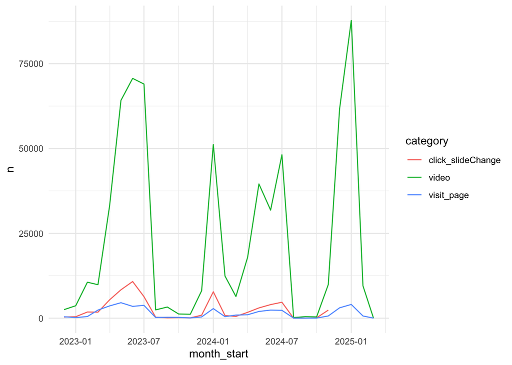

```r
count_action_type_per_month_top3 |>
  ggplot(aes(x = month_start, y = n, color = category, group = category)) +
  geom_line()
```

### 6.1.4 `eventcategory`

Was machen die Visitors eigentlich? Und wie oft?

```r
data_slim_filtered_count <-
data_slim_filtered |>
  filter(type == "eventcategory") |>
  count(value, sort = TRUE)

data_slim_filtered_count |>
  gt()
```

| value | n |
| --- | --- |
| videoplayer_click | 646885 |
| clear_transcript_text_for_llm_context | 104108 |
| click_slideChange | 61934 |
| click_button | 20409 |
| click_transcript_word | 7882 |
| click_videocard | 7164 |
| verify_option_wrong | 4255 |
| login | 4147 |
| click_topic_position_using_image | 2229 |
| click_in_media_search_results | 1268 |
| in_media_search | 1036 |
| generate_questionaire | 1014 |
| generate_questionaire_interval_minutes | 1014 |
| click_start_resize | 975 |
| click_stop_resize | 942 |
| in_media_search_results | 890 |
| verify_option_correct | 708 |
| click_channelcard | 587 |
| click_videocard_search_lecturer | 537 |
| logout | 519 |
| select_transcript_text_for_llm_context | 468 |
| click_videocard_search_course_acronym | 402 |
| click_option | 338 |
| message_to_llm | 279 |
| message_to_llm_de | 258 |
| eval | 240 |
| llm_response_de | 230 |
| click_topic_position_using_link | 213 |
| press_enter | 211 |
| click_topic_details | 181 |
| click_toggle | 171 |
| click_videocard_search_semester | 104 |
| click_channelcard_search_course_acronym | 80 |
| userRole | 75 |
| click_videocard_search_course | 57 |
| click_channelcard_search_faculty_acronym | 33 |
| click_channelcard_search_lecturer | 33 |
| message_to_llm_en | 27 |
| llm_response_en | 26 |
| click_channelcard_search_course | 20 |
| click_channelcard_search_semester | 10 |
| click_channelcard_search_faculty | 7 |
| click_link | 5 |
| click_survey | 3 |
| click_chat_message_thumbs_down | 1 |
| click_chat_message_thumbs_up | 1 |

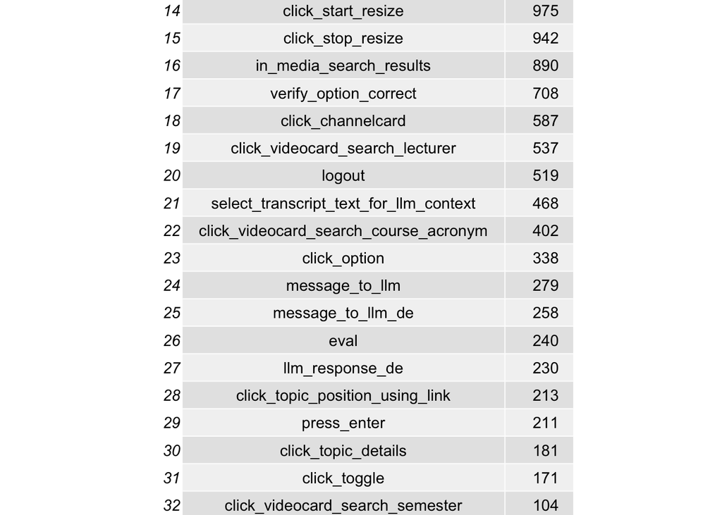

```r
data_slim_filtered_count |>
  ggtexttable()
```

## 6.2 Verteilung

### 6.2.1 Rohwerte

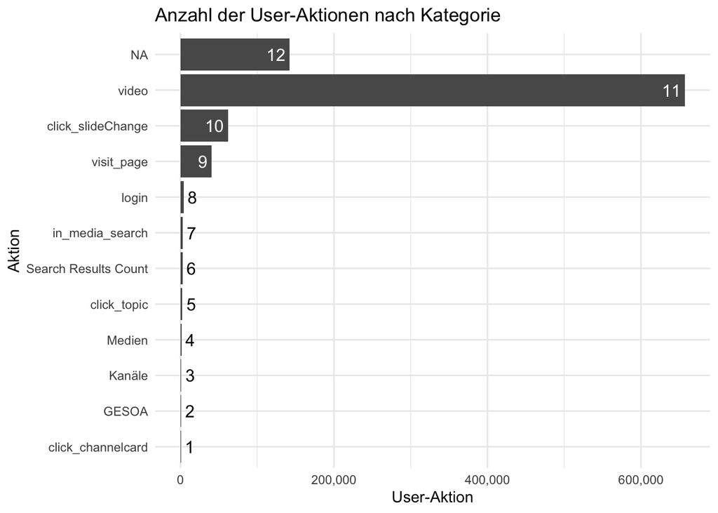

```r
count_action_type |>
  count(category, sort = TRUE) |>
  ggplot(aes(y = reorder(category, n), x = n)) +
  geom_col() +
  geom_bar_text() +
  labs(
    x = "User-Aktion",
    y = "Aktion",
    title = "Anzahl der User-Aktionen nach Kategorie"
  ) +
  theme_minimal() +
  scale_x_continuous(labels = scales::comma)
```

### 6.2.2 Log-Skalierung

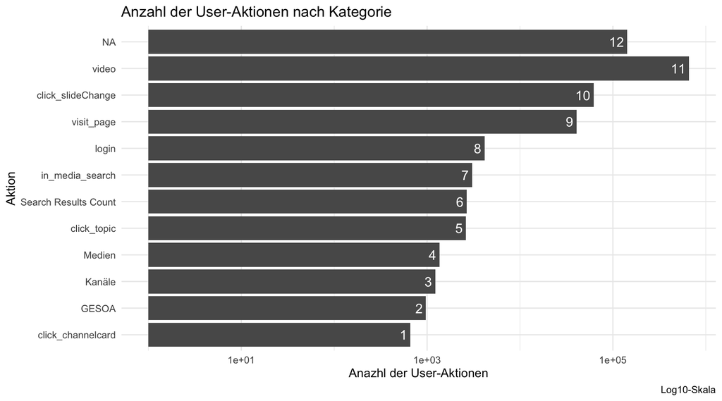

```r
count_action_type |>
  count(category, sort = TRUE) |>
  ggplot(aes(y = reorder(category, n), x = n)) +
  geom_col() +
  geom_bar_text() +
  labs(
    x = "Anazhl der User-Aktionen",
    y = "Aktion",
    title = "Anzahl der User-Aktionen nach Kategorie",
    caption = "Log10-Skala"
  ) +
  theme_minimal() +
  scale_x_log10()
```

# 7 An welchen Tagen und zu welcher Zeit kommen die User zu HaNS?

## 7.1 Setup

```r
tar_load(time_visit_wday)
```

```r
# Define a vector with the names of the days of the week
# Note: Adjust the start of the week (Sunday or Monday) as per your requirement
days_of_week <- c("Monday", "Tuesday", "Wednesday", "Thursday", "Friday", "Saturday", "Sunday")

# Replace numbers with day names
time_visit_wday$dow2 <- factor(days_of_week[time_visit_wday$dow],
                               levels = days_of_week)
```

## 7.2 HaNS-Login nach Uhrzeit

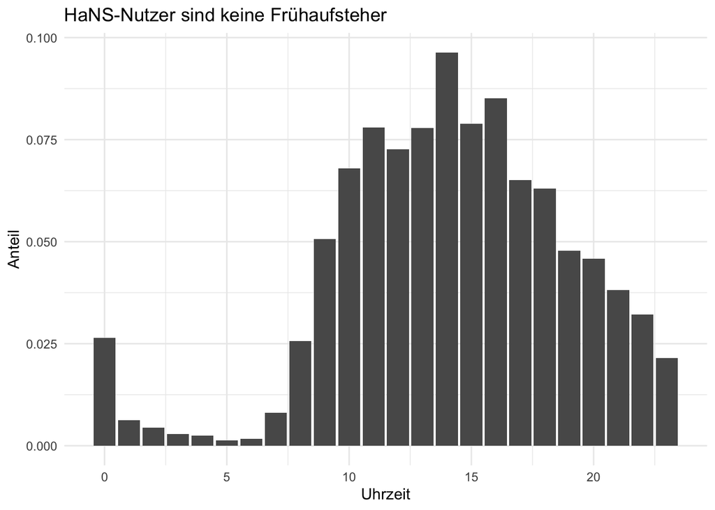

```r
time_visit_wday |>
  as_tibble() |>
  count(hour) |>
  mutate(prop = n/sum(n)) |>
  ggplot(aes(x = hour, y = prop)) +
  geom_col() +
  theme_minimal() +
  labs(
    title = "HaNS-Nutzer sind keine Frühaufsteher",
    x = "Uhrzeit",
    y = "Anteil"
  )
```

```r
 # coord_polar()
```

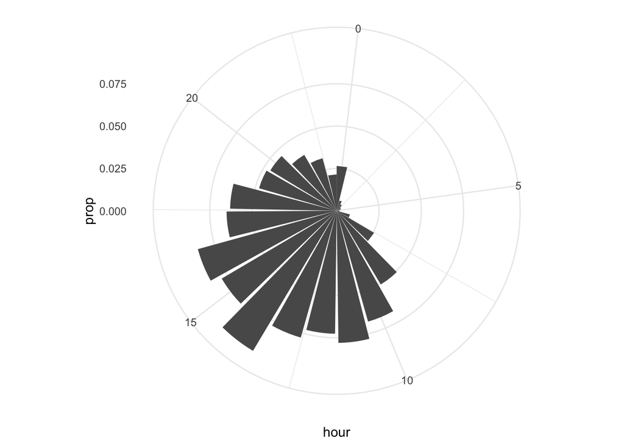

```r
time_visit_wday |>
  as_tibble() |>
  count(hour) |>
  mutate(prop = n/sum(n)) |>
  ggplot(aes(x = hour, y = prop)) +
  geom_col() +
  theme_minimal() +
  coord_polar()
```

## 7.3 Verteilung der HaNS-Besuche nach Wochentagen

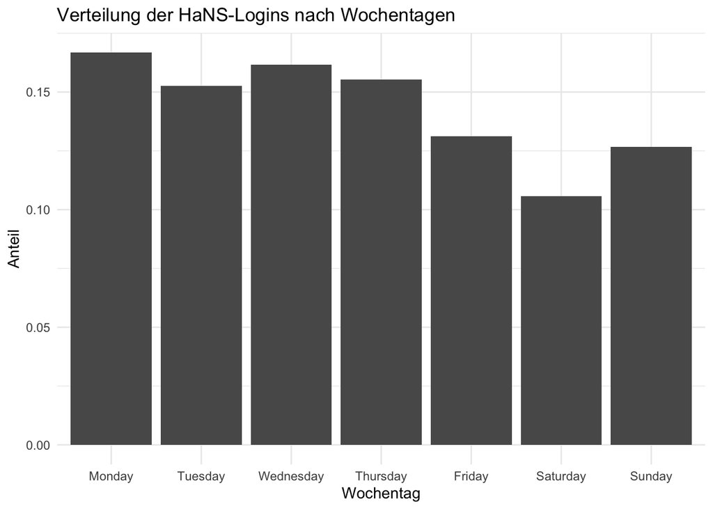

```r
time_visit_wday |>
  as_tibble() |>
  count(dow2) |>
  mutate(prop = n/sum(n)) |>
  ggplot(aes(x = dow2, y = prop)) +
  geom_col() +
  theme_minimal() +
  labs(title = "Verteilung der HaNS-Logins nach Wochentagen",
       x = "Wochentag",
       y = "Anteil")
```

```r
 # coord_polar()
```

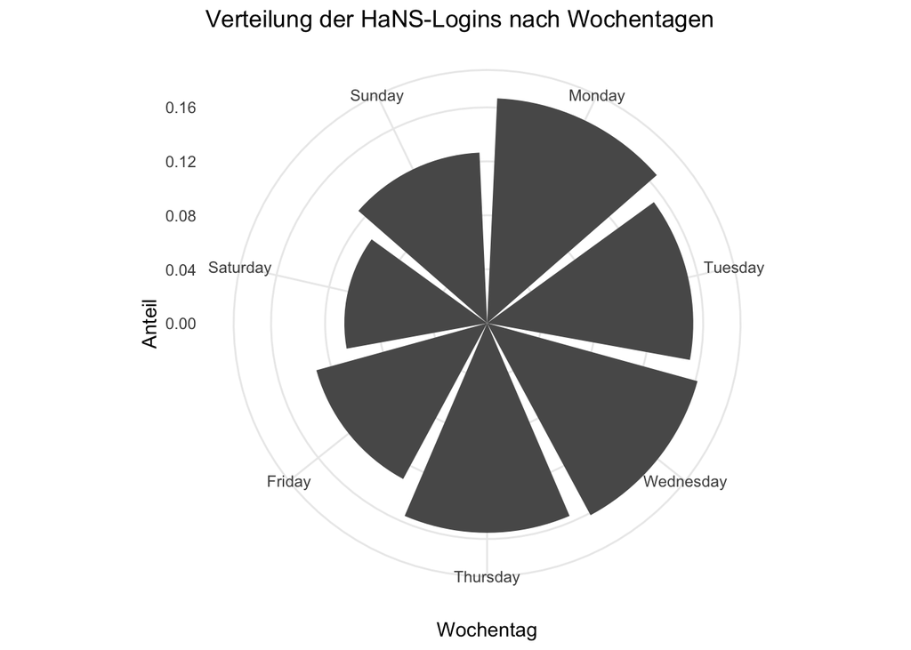

```r
time_visit_wday |>
  as_tibble() |>
  count(dow2) |>
  mutate(prop = n/sum(n)) |>
  ggplot(aes(x = dow2, y = prop)) +
  geom_col() +
  theme_minimal() +
  labs(title = "Verteilung der HaNS-Logins nach Wochentagen",
       x = "Wochentag",
       y = "Anteil")  +
  coord_polar()
```